# Pengaruh Lag

Fatima Azzahra - G1401231036

2025-09-09

```r
library(readr)
library(dplyr)
```

```r
library(ggplot2)
library(dLagM)
library(dynlm)
library(MLmetrics)
library(lmtest)
```

# Tahap 1: Penyiapan Data

**Import Dataset**

```r
air <- read.csv("D:\\TAHUN 3\\G1_MPDW\\P3\\NewDelhi_Air_quality.csv")
View(air)
```

```r
# Cek struktur dataset
str(air)
```

```
## 'data.frame':    72 obs. of  12 variables:
##  $ X              : int  0 1 2 3 4 5 6 7 8 9 ...
##  $ AQI            : num  30.2 28.2 26.6 25 26 26 26 24 23 24 ...
##  $ CO             : num  199 198 199 202 205 ...
##  $ datetime       : chr  "2022-10-21:18" "2022-10-21:19" "2022-10-21:20" "2022-10-21:21" ...
##  $ no2            : num  0.0469 0.0465 0.0469 0.0482 0.0489 ...
##  $ o3             : num  55.8 54.9 54.6 55.1 55.8 ...
##  $ pm10           : num  10.5 10.7 11.2 11.1 10.4 ...
##  $ pm25           : num  5.64 4.62 3.52 2.23 1.98 ...
##  $ so2            : num  0.387 0.41 0.402 0.376 0.339 ...
##  $ timestamp_local: chr  "2022-10-21T23:00:00" "2022-10-22T00:00:00" "2022-10-22T01:00:00" "2022-10-22T02:00:00" ...
##  $ timestamp_utc  : chr  "2022-10-21T18:00:00" "2022-10-21T19:00:00" "2022-10-21T20:00:00" "2022-10-21T21:00:00" ...
##  $ ts             : int  1666375200 1666378800 1666382400 1666386000 1666389600 1666393200 1666396800 1666400400 1666404000 1666407600 ...
```

**Formatting kolom timestamp_utc dari chr ke datetime**

```r
library(lubridate)
air$timestamp_utc <- ymd_hms(air$timestamp_utc, tz = "UTC")
```

**Cek duplikasi data**

```r
sum(duplicated(air$timestamp_utc))
```

```
## [1] 0
```

**Cek kelengkapan deret waktu**

```r
time_full <- seq(min(air$timestamp_utc), max(air$timestamp_utc), by = "1 hour")
missing_times <- setdiff(time_full, air$timestamp_utc)
length(missing_times)
```

```
## [1] 0
```

# Tahap 2: Pemilihan peubah X

## A. Korelasi Polutan dengan AQI

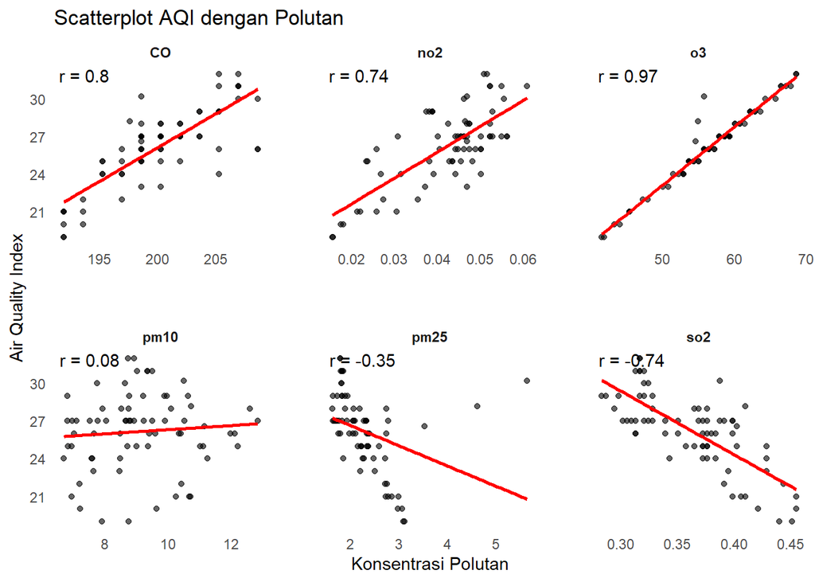

```r
library(tidyr)

# Ubah ke long format
air_long <- air %>%
  pivot_longer(cols = c(pm25, pm10, CO, so2, no2, o3),
               names_to = "Polutan",
               values_to = "Konsentrasi")

# Hitung korelasi per polutan
cor_vals <- air_long %>%
  group_by(Polutan) %>%
  summarise(r = cor(AQI, Konsentrasi, use = "complete.obs", method = "pearson"))

# Plot dengan korelasi ditulis manual
ggplot(air_long, aes(x = Konsentrasi, y = AQI)) +
  geom_point(alpha=0.6) +
  geom_smooth(method = "lm", se = FALSE, color = "red") +
  facet_wrap(~Polutan, scales = "free_x") +
  geom_text(data = cor_vals,
            aes(x = -Inf, y = Inf,
                label = paste0("r = ", round(r, 2))),
            hjust = -0.1, vjust = 1.2, inherit.aes = FALSE) +
  labs(x="Konsentrasi Polutan", y="Air Quality Index", title = "Scatterplot AQI dengan Polutan") +
  theme_minimal() +
  theme(
    panel.grid = element_blank(),               # hapus grid
    panel.spacing = unit(1.2, "cm"),            # jarak antar facet
    strip.text = element_text(face = "bold")    # tebal nama facet (judul tiap polutan)
  )
```

Berdasarkan scatterplot, Polutan Ozon ($O_3$) memiliki korelasi positif paling tinggi sebesar 0.97. Kuatnya hubungan linier antar kedua peubah ini menjadi alasan pertama dalam pemilihan Ozon ($O_3$) sebagai peubah X dalam pemodelan.

## B. Literatur Terkait

**Ozon**  
Ozon adalah polutan sekunder yang terbentuk ketika gas Nitrogen Oksida ($NO_x$) bercampur dengan senyawa organik volatil lain di udara, lalu bereaksi karena sinar matahari. Berbeda dengan Ozon Stratosfer yang berperan sebagai pelindung dari paparan sinar UV, Ozon Toposfer atau yang terbentuk di dekat permukaan tanah dapat berdampak serius bagi kesehatan dan perubahan iklim.

Paparan jangka panjang terhadap ozon ini dapat berakibat pada Penyakit Paru Obstruktif Kronis (PPOK) yang berkembang secara perlahan dan membuat orang semakin kesulitan bernapas. Diperkirakan ada 489.000 kasus kematian di seluruh dunia akibat paparan Ozon, dimana 5.010 diantaranya terjadi di Indonesia (Data 2021).

Pencemaran Ozon juga berpengaruh terhadap perubahan iklim karena Ozon termasuk gas rumah kaca yang ikut menyumbang peningkatan suhu global. Pembentukan Ozon juga dapat dipercepat seiring menghangatnya udara atau gelombang panas.

Sumber: *Ozone*. State of Global Air.[diakses 2025 Sep 14]. https://www.stateofglobalair.org/pollution-sources/ozone

**Perhitungan AQI**  
AQI dihitung dengan cara mengonversi nilai masing-masing polutan ($CO, NO_2, O_3, PM_{10}, PM_{2.5}, SO_2$) menjadi skor AQI dengan rumus baku. Dari hasil tersebut, nilai AQI final ditentukan oleh polutan dengan skor tertinggi, karena polutan itulah yang paling berbahaya dan berisiko bagi kesehatan pada saat itu. Jadi, meskipun polutan lain rendah, satu polutan dengan skor tinggi sudah cukup untuk menurunkan kualitas udara secara keseluruhan.

- 0–50: Udara baik, tidak berisiko bagi kesehatan.
- 51–100: Sedang, umumnya aman tapi sebagian orang bisa merasa tidak nyaman.
- 101–150: Tidak sehat bagi kelompok sensitif, bisa muncul gangguan pernapasan.
- 151–200: Tidak sehat, mulai berdampak pada masyarakat umum.
- 201–300: Sangat tidak sehat, peringatan kesehatan darurat, semua orang berisiko terdampak.
- 301–500: Berbahaya, dampak serius seperti sesak napas, iritasi saluran pernapasan, hingga ancaman keselamatan.

Sumber: Shikha Sharma. 2021 Sep 27. *What is Air Quality Index (AQI) & How Is It Calculated?*. Prana Air.[diakses 2025 Sep 14]. https://www.pranaair.com/blog/what-is-air-quality-index-aqi-and-its-calculation/

# Tahap 3: Eksplorasi Data

```r
# Formatting data jadi time series dengan fungsi ts()
aqi.ts <- ts(air$AQI)
summary(aqi.ts)
```

```
##    Min. 1st Qu.  Median    Mean 3rd Qu.    Max.
##   19.00   25.00   27.00   26.18   28.00   32.00
```

```r
aqi.ts
```

```
## Time Series:
## Start = 1
## End = 72
## Frequency = 1
##  [1] 30.2 28.2 26.6 25.0 26.0 26.0 26.0 24.0 23.0 24.0 25.0 26.0 27.0 29.0 29.0
## [16] 29.0 29.0 28.0 27.0 27.0 27.0 27.0 27.0 27.0 27.0 28.0 29.0 31.0 31.0 32.0
## [31] 32.0 31.0 31.0 30.0 30.0 29.0 27.0 26.0 25.0 25.0 24.0 24.0 25.0 25.0 25.0
## [46] 26.0 26.0 27.0 27.0 27.0 27.0 28.0 28.0 27.0 27.0 26.0 25.0 23.0 22.0 21.0
## [61] 20.0 19.0 19.0 20.0 21.0 21.0 21.0 22.0 24.0 26.0 27.0 28.0
```

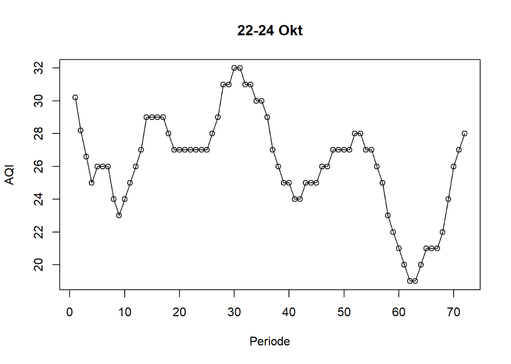

```r
ts.plot(aqi.ts, xlab="Periode", ylab="AQI",
        main = "22-24 Okt")
points(aqi.ts)
```

```r
# Formatting data jadi time series dengan fungsi ts()
o3.ts <- ts(air$o3)
summary(o3.ts)
```

```
##    Min. 1st Qu.  Median    Mean 3rd Qu.    Max.
##   41.48   53.64   57.22   56.57   60.08   68.66
```

```r
o3.ts
```

```
## Time Series:
## Start = 1
## End = 72
## Frequency = 1
##  [1] 55.78995 54.93164 54.64554 55.07469 55.78995 56.50520 55.78995 52.92892
##  [9] 50.06790 51.49841 53.64418 55.78995 59.36623 62.22725 62.94250 62.94250
## [17] 62.22725 60.79674 59.36623 58.65097 58.65097 57.93572 57.93572 58.65097
## [25] 59.36623 61.51199 63.65776 66.51878 67.94930 68.66455 68.66455 67.23404
## [33] 66.51878 65.80353 64.37302 62.22725 59.36623 56.50520 55.07469 53.64418
## [41] 52.92892 52.92892 53.64418 53.64418 54.35944 55.78995 57.22046 57.93572
## [49] 58.65097 58.65097 59.36623 60.08148 60.08148 59.36623 58.65097 57.22046
## [57] 54.35944 50.78316 47.92213 45.41874 43.98823 41.84246 41.48483 43.27297
## [65] 45.41874 45.41874 45.41874 47.20688 52.21367 56.50520 59.36623 60.79674
```

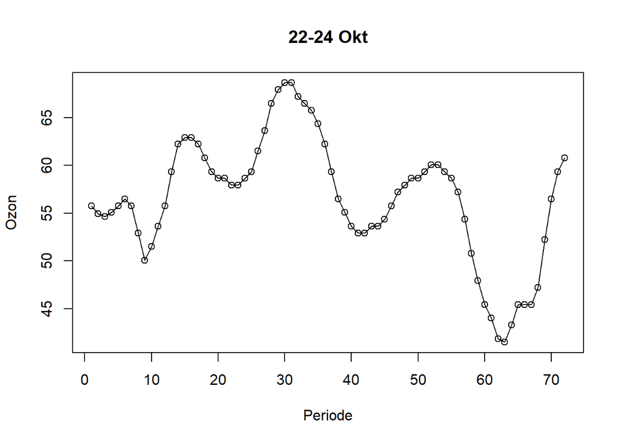

```
## integer(0)
```

```r
ts.plot(o3.ts, xlab="Periode", ylab="Ozon",
        main = "22-24 Okt") +
points(o3.ts)
```

```r
# Formatting data jadi time series dengan fungsi ts()
so2.ts <- ts(air$so2)
co.ts <- ts(air$CO)
no2.ts <- ts(air$no2)
pm10.ts <- ts(air$pm10)
pm25.ts <- ts(air$pm25)
```

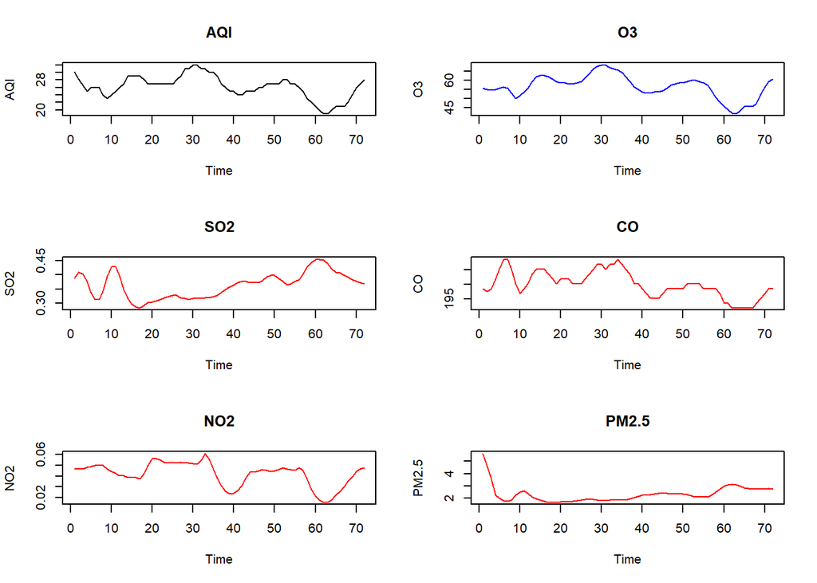

```r
par(mfrow = c(3, 2))  # grid 4 baris x 2 kolom

ts.plot(aqi.ts, main = "AQI", xlab="Time", ylab="AQI", col="black")
ts.plot(o3.ts, main = "O3", xlab="Time", ylab="O3", col="blue")
ts.plot(so2.ts, main = "SO2", xlab="Time", ylab="SO2", col="red")
ts.plot(co.ts, main = "CO", xlab="Time", ylab="CO", col="red")
ts.plot(no2.ts, main = "NO2", xlab="Time", ylab="NO2", col="red")
ts.plot(pm25.ts, main = "PM2.5", xlab="Time", ylab="PM2.5", col="red")
```

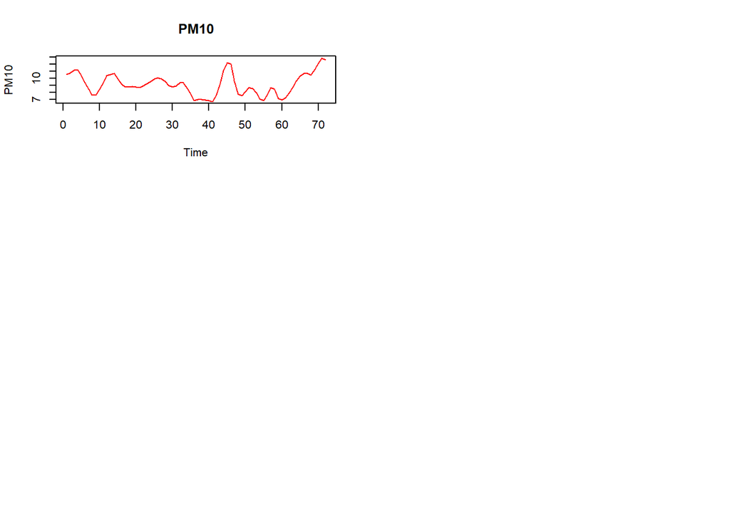

```r
ts.plot(pm10.ts, main = "PM10", xlab="Time", ylab="PM10", col="red")

par(mfrow = c(1,1))  # reset layout
```

Terdapat kemiripan antara pola time series skor AQI dengan Ozon. Hal ini dapat mengindikasikan adanya dominansi Ozon dalam penentuan skor akhir AQI. Hal ini menarik untuk dianalisis lebih lanjut terutama untuk mengetahui polutan mana yang paling berpengaruh signifikan terhadap penentuan skor AQI (konteks analisis regresi) dan mengetahui apakah Ozon menyebabkan fluktuasi AQI (konteks analisis deret waktu).

```r
summary(air$AQI)
```

```
##    Min. 1st Qu.  Median    Mean 3rd Qu.    Max.
##   19.00   25.00   27.00   26.18   28.00   32.00
```

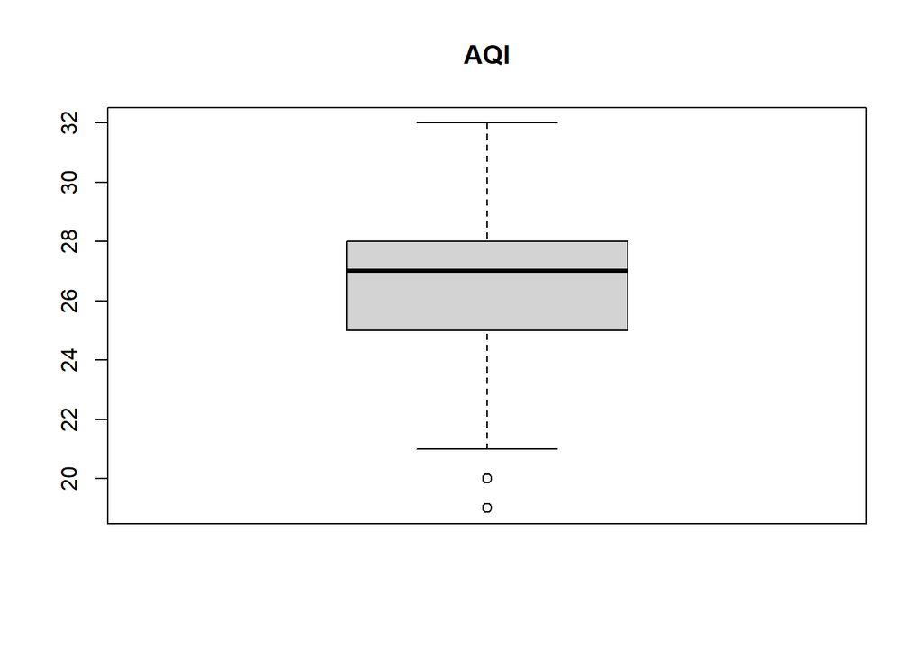

```r
boxplot(air$AQI, main = "AQI")
```

```r
summary(air$o3)
```

```
##    Min. 1st Qu.  Median    Mean 3rd Qu.    Max.
##   41.48   53.64   57.22   56.57   60.08   68.66
```

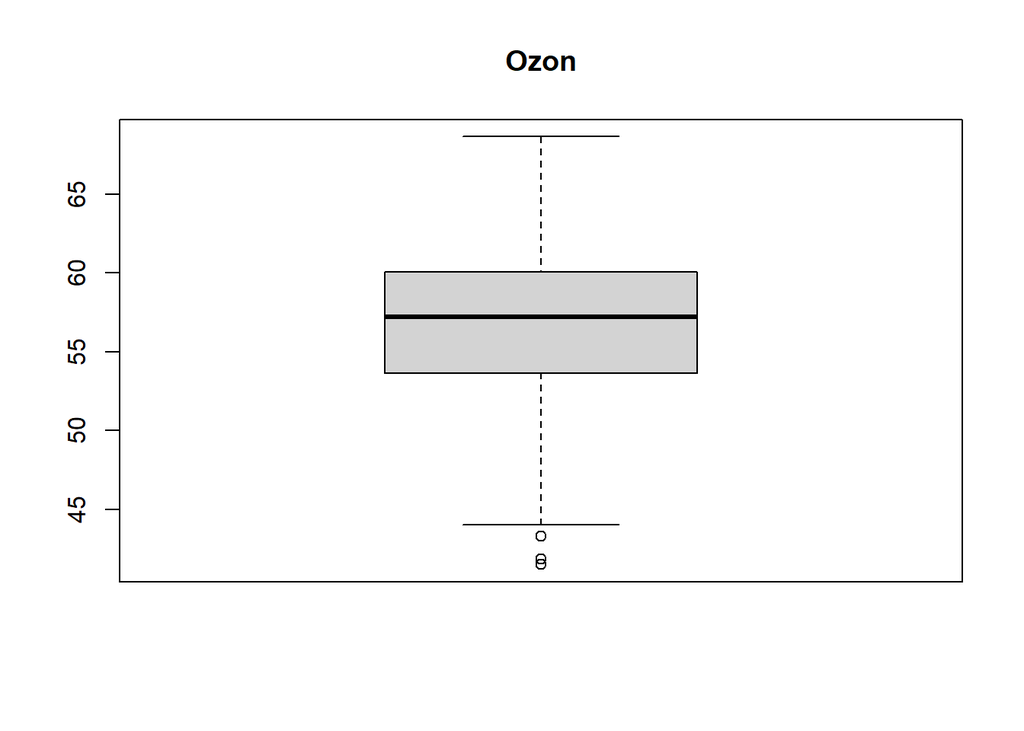

```r
boxplot(air$o3, main = "Ozon")
```

Skor AQI 19 - 32 menunjukkan kualitas udara berada dalam rentang yang sangat baik, sedangkan pada Ozon mediannya sebesar 57.22 masuk dalam rentang moderat atau meninmbulkan ketidaknyamanan bagi kelompok yang sensitif. Beberapa outlier hanya terdapat pada skor kecil (indikasi kualitas udara yang baik).

# Tahap 4: Pengecekan asumsi

## A. Asumsi Autokorelasi

```r
Y <- air$AQI
X <- air$o3
model <- lm(Y ~ X)
summary(model)
```

```
##
## Call:
## lm(formula = Y ~ X)
##
## Residuals:
##     Min      1Q  Median      3Q     Max
## -0.5039 -0.4436 -0.1381  0.1810  4.3810
##
## Coefficients:
##             Estimate Std. Error t value Pr(>|t|)
## (Intercept)  0.02128    0.73771   0.029    0.977
## X            0.46241    0.01296  35.685   <2e-16 ***
## ---
## Signif. codes:  0 '***' 0.001 '**' 0.01 '*' 0.05 '.' 0.1 ' ' 1
##
## Residual standard error: 0.7022 on 70 degrees of freedom
## Multiple R-squared:  0.9479, Adjusted R-squared:  0.9472
## F-statistic:  1273 on 1 and 70 DF,  p-value: < 2.2e-16
```

```r
sisaan <- residuals(model)
```

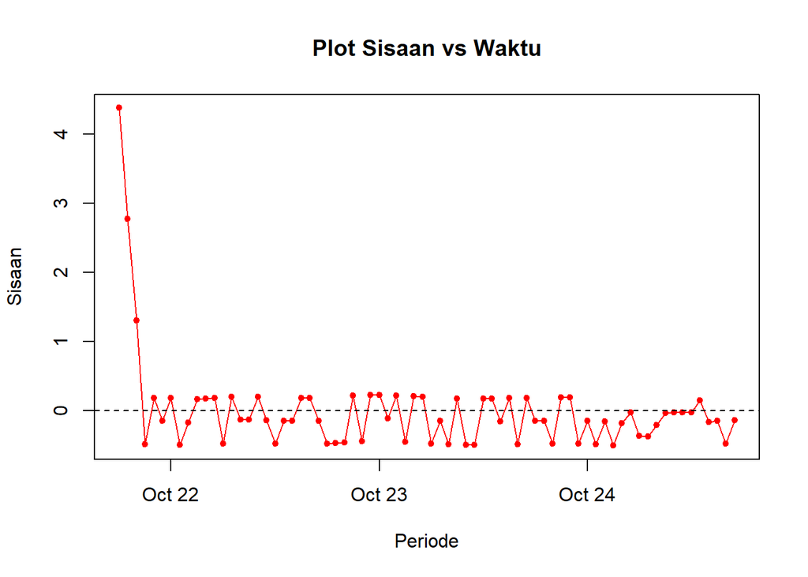

```r
plot(air$timestamp_utc, sisaan, type="o", pch=20, col="red",
     main="Plot Sisaan vs Waktu", xlab="Periode", ylab="Sisaan")
abline(h=0, lty=2)
```

**Kecurigaan:**  
Plot di atas menunjukkan adanya pola yang **tidak acak**. Terdapat sisaan yang cenderung berpola linier sehingga mengindikasikan adanya autokorelasi.

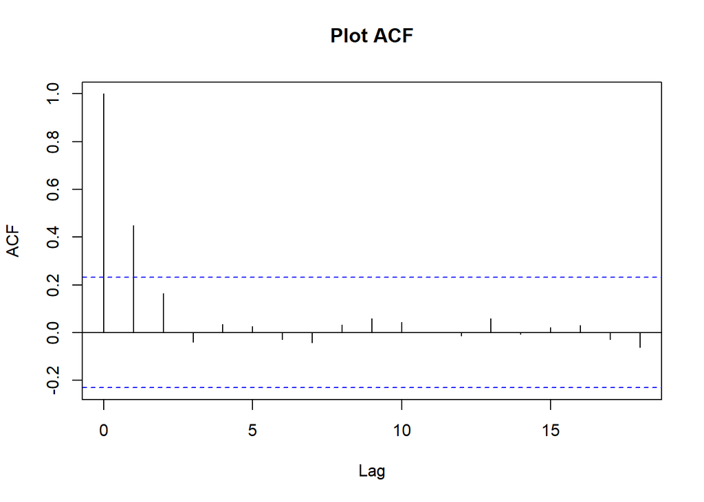

```r
acf(sisaan, main = "Plot ACF")
```

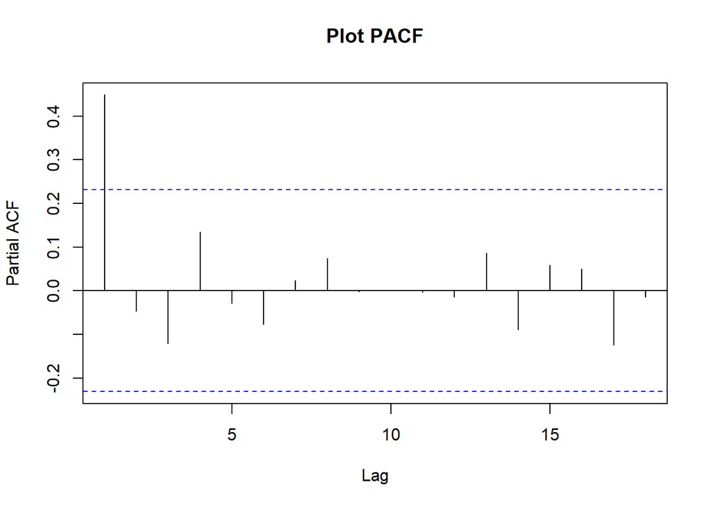

```r
pacf(sisaan, main = "Plot PACF")
```

**Kecurigaan:**  
Terdapat indikasi autokorelasi di lag-1.

```r
dwtest(model)
```

```
##
##  Durbin-Watson test
##
## data:  model
## DW = 0.54636, p-value = 3.207e-14
## alternative hypothesis: true autocorrelation is greater than 0
```

**Hasil Investigasi:**

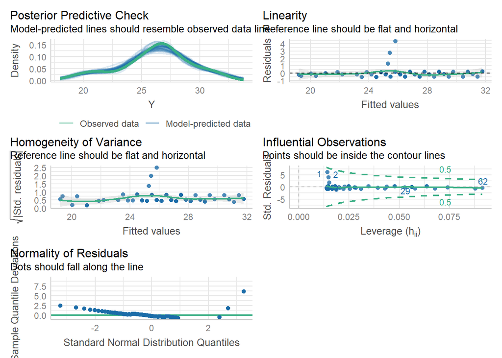

```r
library(performance)
library(sjPlot)
check_model(model)
```

Berdasarkan uji grafik ini, tidak terdapat amatan berpengaruh yang dapat mengganggu model. Asumsi lainnya dicek lebih lanjut dengan uji formal berikut:

**Normalitas Sisaan** Sisaan tidak menyebar normal.

```r
shapiro.test(sisaan)
```

```
##
##  Shapiro-Wilk normality test
##
## data:  sisaan
## W = 0.51931, p-value = 5.517e-14
```

**Homogenitas Ragam Sisaan** Ragam sisaan homogen.

```r
bptest(model)
```

```
##
##  studentized Breusch-Pagan test
##
## data:  model
## BP = 0.039736, df = 1, p-value = 0.842
```

**Nilai Harapan Sisaan** Nilai Harapan Sisaan = 0.

```r
t.test(sisaan, mu = 0,conf.level = 0.95)
```

```
##
##  One Sample t-test
##
## data:  sisaan
## t = 2.8422e-15, df = 71, p-value = 1
## alternative hypothesis: true mean is not equal to 0
## 95 percent confidence interval:
##  -0.1638504  0.1638504
## sample estimates:
##    mean of x
## 2.335531e-16
```

**Hasil Investigasi:**

- Asumsi normalitas sisaan belum terpenuhi.

# Tahap 5: Regresi dengan Peubah Lag

```r
rl <- air %>%
  select(timestamp_utc, AQI, o3)
```

## Splitting Data

```r
n <- nrow(rl)
train_size <- floor(0.8 * n)

train <- rl[1:train_size, ]
test <- rl[(train_size + 1):n, ]
```

```r
Y <- rl$AQI
X <- rl$o3
train_Y <- window(Y, end = time(Y)[train_size])
train_X <- window(X, end = time(X)[train_size])

test_Y <- window(Y, start = time(Y)[train_size + 1])
test_X <- window(X, start = time(X)[train_size + 1])
```

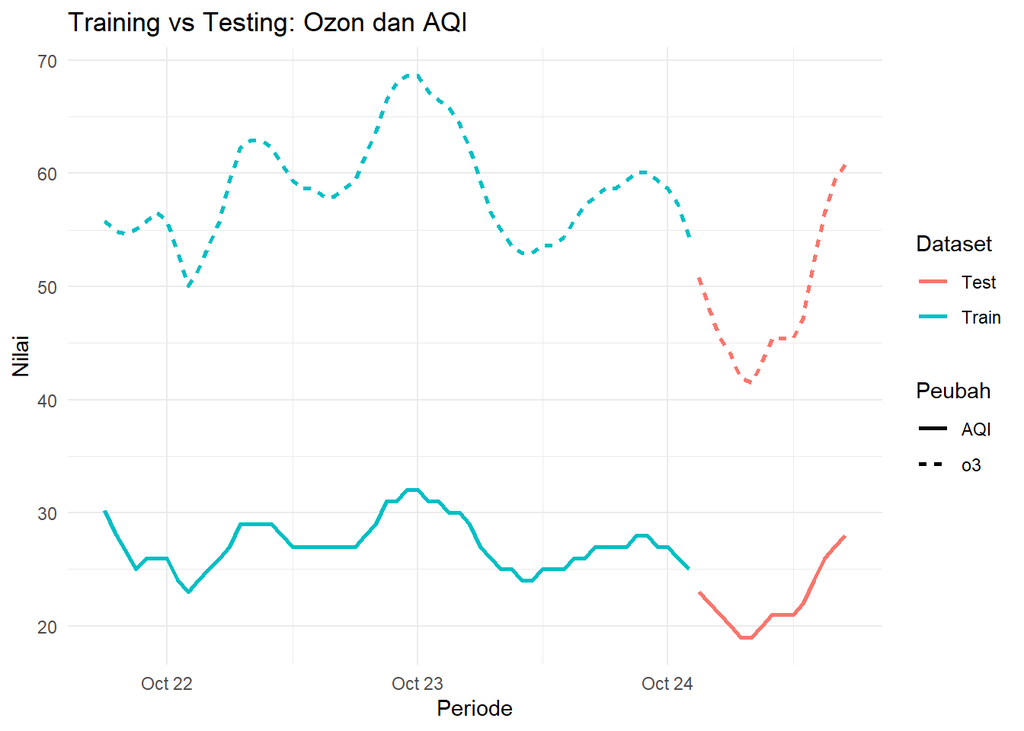

```r
rl <- rl %>%
  mutate(dataset = ifelse(row_number() <= train_size, "Train", "Test"))

rl_long <- rl %>%
  pivot_longer(cols = c(AQI, o3), names_to = "Peubah", values_to = "Nilai")

ggplot(rl_long, aes(x = timestamp_utc, y = Nilai, color = dataset, linetype = Peubah)) +
  geom_line(size = 1) +
  labs(title = "Training vs Testing: Ozon dan AQI",
       x = "Periode",
       color = "Dataset",
       linetype = "Peubah") +
  theme_minimal()
```

## A. Koyck Model

**Intuisi:** Model Koyck memiliki asumsi **pengaruh dari masa lalu akan semakin melemah seiring berjalannya waktu**.

Secara matematis, Koyck menyederhanakan model yang memiliki tak hingga lag menjadi model yang jauh lebih simpel dengan memasukkan **lag dari variabel dependen** $(Y_{t−1})$ sebagai salah satu prediktor. $Y_{t−1}$ ini secara implisit sudah merangkum semua informasi dari lag X di masa lalu.

**Formula Umum:**
$$y_t=a(1-\lambda)+\beta_0X_t+\beta_1Z_t+\lambda Y_{t-1}+V_t$$
dengan
$$V_t=u_t-\lambda u_{t-1}$$
Di mana $\lambda$ (koefisien dari $Y_{t−1}$) menunjukkan “tingkat peluruhan” atau seberapa cepat pengaruh masa lalu memudar.

**PEMODELAN**

```r
train.ts<-ts(train)
test.ts<-ts(test)
rl.ts<-ts(rl)
```

```r
model.koyck <- koyckDlm(x = train$o3, y = train$AQI)
summary(model.koyck)
```

```
##
## Call:
## "Y ~ (Intercept) + Y.1 + X.t"
##
## Residuals:
##       Min        1Q    Median        3Q       Max
## -1.127670 -0.301407  0.001002  0.262601  1.103471
##
## Coefficients:
##             Estimate Std. Error t value Pr(>|t|)
## (Intercept)  0.54798    0.92878   0.590    0.558
## Y.1          0.41955    0.08223   5.102 4.63e-06 ***
## X.t          0.25830    0.04107   6.289 6.25e-08 ***
## ---
## Signif. codes:  0 '***' 0.001 '**' 0.01 '*' 0.05 '.' 0.1 ' ' 1
##
## Residual standard error: 0.5053 on 53 degrees of freedom
## Multiple R-Squared: 0.9463,  Adjusted R-squared: 0.9443
## Wald test: 423.7 on 2 and 53 DF,  p-value: < 2.2e-16
##
## Diagnostic tests:
## NULL
##
##                             alpha      beta       phi
## Geometric coefficients:  0.944071 0.2582957 0.4195528
```

```r
AIC(model.koyck)
```

```
## [1] 87.39413
```

```r
BIC(model.koyck)
```

```
## [1] 95.49554
```

**Interpretasi Hasil:**

- Dari `summary`, kita dapatkan model:

  $$\hat{Y_t}=0.54798+0.25830X_t+0.41955Y_{t-1}$$
- Koefisien $X_t$ (0.25830) signifikan, artinya nilai $X$ saat ini berpengaruh terhadap $Y$.
- Koefisien $Y_{t−1}$ (0.41955) juga signifikan. Ini adalah **estimasi** $\lambda$. Nilai ini menunjukkan bahwa sekitar 42% dari efek di periode sebelumnya masih “terbawa” ke periode saat ini.

**PERAMALAN DAN AKURASI**

Berikut adalah hasil peramalan y untuk 15 periode kedepan menggunakan model koyck

```r
fore.koyck <- dLagM::forecast(model = model.koyck, x = test$o3, h=nrow(test))
fore.koyck
```

```
## $forecasts
##  [1] 24.15387 23.05989 21.95429 21.12094 20.21706 19.74546 20.00947 20.67448
##  [9] 20.95348 21.07054 21.58152 23.08914 24.83015 26.29958 27.28558
##
## $call
## forecast.koyckDlm(model = model.koyck, x = test$o3, h = nrow(test))
##
## attr(,"class")
## [1] "forecast.koyckDlm" "dLagM"
```

```r
mape.koyck <- MAPE(fore.koyck$forecasts, test$AQI)
mape.koyck # MAPE Data Test
```

```
## [1] 0.03187326
```

```r
GoF(model.koyck) # Akurasi Data Training
```

```
##              n       MAE         MPE       MAPE      sMAPE      MASE       MSE
## model.koyck 56 0.3849916 -0.00049635 0.01435646 0.01433475 0.6015494 0.2416839
##                  MRAE    GMRAE
## model.koyck 589435374 7663.933
```

- **MAPE (test) = 3.2%**
- **MAPE (train) = 1.4%**

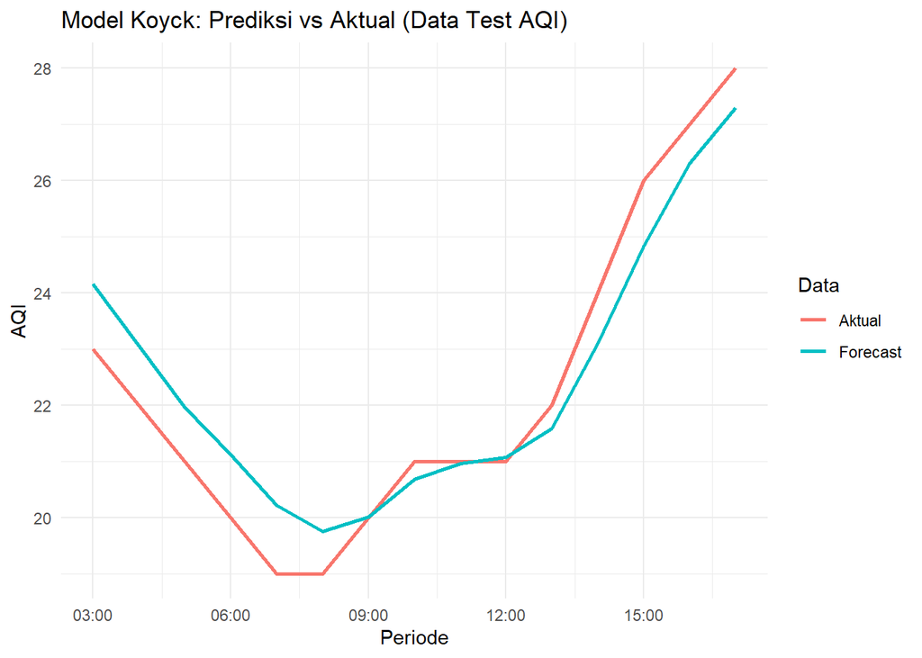

```r
koyck_plot <- data.frame(
  Time = test$timestamp_utc,
  Actual = test$AQI,
  Predicted = fore.koyck$forecasts
)

ggplot(koyck_plot, aes(x = Time)) +
  geom_line(aes(y = Actual, color = "Aktual"), size = 1) +
  geom_line(aes(y = Predicted, color = "Forecast"), size = 1) +
  labs(title = "Model Koyck: Prediksi vs Aktual (Data Test AQI)",
       x = "Periode",
       y = "AQI",
       color = "Data") +
  theme_minimal()
```

## B. Distributed Lag Model

**Intuisi:** Model DLM lebih fleksibel dengan **tidak membuat asumsi** tentang pola peluruhan pengaruh. Sebaliknya, dilakukan estimasi koefisien untuk **setiap lag secara terpisah**.

**Tantangan:** Menentukan berapa banyak lag yang berpengaruh agar tidak kehilangan informasi penting ataupun overfitting.

**PENENTUAN LAG OPTIMUM**

```r
finiteDLMauto(formula = AQI ~ o3,
              data = data.frame(train), q.min = 1, q.max = 30,
              model.type = "dlm", error.type = "AIC", trace = TRUE)
```

```
##    q - k    MASE       AIC       BIC       GMRAE   MBRAE R.Adj.Sq    Ljung-Box
## 28    28 0.00000      -Inf      -Inf     0.00000 0.23214      NaN          NaN
## 29    29 0.00000      -Inf      -Inf     0.00001 0.24074      NaN          NaN
## 30    30 0.00000      -Inf      -Inf     0.00000 0.23077      NaN          NaN
## 27    27 0.02635 -98.74046 -56.70454   700.80724 0.48422  0.99855 1.003442e-06
## 26    26 0.14617   6.69175  48.27738  2786.22270 0.47258  0.98071 2.922612e-02
## 24    24 0.16195   7.30793  47.71364  1935.58808 0.44107  0.98809 1.089871e-02
## 20    20 0.21436   9.02229  46.07340  8480.08731 0.50697  0.98944 5.954627e-03
## 25    25 0.16818  11.53063  52.57124  2600.55669 0.45933  0.98392 6.227461e-03
## 14    14 0.31146  12.26243  42.20283 21454.38751 0.53285  0.98747 2.509123e-01
## 21    21 0.21203  12.26942  50.27388  6348.70007 0.49094  0.98838 7.493378e-03
## 19    19 0.24685  13.43278  49.45968 12923.53438 0.52426  0.98806 1.004669e-02
## 18    18 0.27339  14.65229  49.58709 17433.46363 0.53760  0.98753 2.546957e-03
## 22    22 0.19973  14.74048  53.62418  3805.47607 0.47450  0.98720 1.493138e-02
## 15    15 0.30128  14.93845  46.21650 16631.88565 0.52118  0.98690 2.373481e-01
```

[output cut: 16 more lines]

Berdasarkan output tersebut, lag optimum didapatkan ketika **lag = 27** dengan AIC terkecil yaitu -98.74.

**PEMODELAN DLM1: Lag = 27**

```r
model.dlm <- dlm(x = train$o3 , y = train$AQI, q = 27)
summary(model.dlm)
```

```
##
## Call:
## lm(formula = model.formula, data = design)
##
## Residuals:
##          1          2          3          4          5          6          7
## -0.0037911  0.0155363 -0.0302672  0.0305917 -0.0173514  0.0136466 -0.0146469
##          8          9         10         11         12         13         14
##  0.0055162 -0.0137035  0.0342558 -0.0300003  0.0120103 -0.0036722  0.0121875
##         15         16         17         18         19         20         21
## -0.0200194  0.0153783 -0.0071234 -0.0004106 -0.0033758 -0.0007457  0.0146381
##         22         23         24         25         26         27         28
## -0.0142657  0.0095412  0.0023294 -0.0162259  0.0233862 -0.0257940  0.0194216
##         29         30
## -0.0166468  0.0096008
##
## Coefficients:
##             Estimate Std. Error t value Pr(>|t|)
## (Intercept) 52.25144   10.71641   4.876   0.1288
## x.t          0.67298    0.04946  13.605   0.0467 *
## x.1         -0.27779    0.10646  -2.609   0.2330
## x.2         -0.09762    0.09741  -1.002   0.4993
## x.3         -0.29403    0.08852  -3.321   0.1862
## x.4          0.01583    0.08089   0.196   0.8770
## x.5          0.35723    0.07959   4.488   0.1396
## x.6         -0.34753    0.08450  -4.113   0.1518
## x.7          0.39318    0.08428   4.665   0.1344
## x.8         -0.45954    0.07174  -6.406   0.0986 .
## x.9          0.44476    0.06892   6.453   0.0979 .
## x.10         0.17414    0.07262   2.398   0.2515
## x.11        -0.65132    0.07374  -8.833   0.0718 .
## x.12         0.15794    0.07671   2.059   0.2878
## x.13        -0.33887    0.07353  -4.609   0.1360
## x.14         0.29384    0.08165   3.599   0.1725
## x.15        -0.08265    0.08430  -0.980   0.5063
## x.16         0.16463    0.08492   1.939   0.3032
## x.17        -0.45599    0.09212  -4.950   0.1269
## x.18         0.37604    0.09219   4.079   0.1531
## x.19        -0.15989    0.07444  -2.148   0.2774
## x.20         0.23492    0.06530   3.597   0.1726
## x.21        -0.39496    0.06743  -5.858   0.1076
## x.22         0.23166    0.06897   3.359   0.1842
## x.23        -0.50038    0.07375  -6.785   0.0932 .
## x.24         0.42021    0.07699   5.458   0.1154
## x.25        -0.28255    0.07406  -3.815   0.1632
## x.26         0.24318    0.05965   4.077   0.1531
## x.27        -0.24443    0.03966  -6.163   0.1024
## ---
## Signif. codes:  0 '***' 0.001 '**' 0.01 '*' 0.05 '.' 0.1 ' ' 1
##
## Residual standard error: 0.09404 on 1 degrees of freedom
## Multiple R-squared:      1,  Adjusted R-squared:  0.9986
## F-statistic: 716.6 on 28 and 1 DF,  p-value: 0.02953
##
## AIC and BIC values for the model:
##         AIC       BIC
## 1 -98.74046 -56.70454
```

```r
AIC(model.dlm)
```

```
## [1] -98.74046
```

```r
BIC(model.dlm)
```

```
## [1] -56.70454
```

Dari hasil tersebut terdapat beberapa peubah yang berpengaruh signifikan terhadap taraf nyata 5% yaitu $x_t$. Adapun keseluruhan model yang terbentuk adalah

$$\hat{Y_t}=52.25144+0.67298X_t+...-0.24443X_{t-27}$$
Adapun hasil peramalan 15 periode kedepan menggunakan model tersebut adalah sebagai berikut

```r
fore.dlm <- dLagM::forecast(model = model.dlm, x=test$o3, h=nrow(test))
mape.dlm <- MAPE(fore.dlm$forecasts, test$AQI)
mape.dlm
```

```
## [1] 0.2387997
```

```r
GoF(model.dlm)
```

```
##            n      MAE           MPE         MAPE        sMAPE      MASE
## model.dlm 30 0.014536 -4.379667e-07 0.0005253522 0.0005253504 0.0263465
##                    MSE     MRAE    GMRAE
## model.dlm 0.0002947963 57312528 700.8072
```

**PEMODELAN DLM2: Lag = 20**

```r
model.dlm2 <- dlm(x = train$o3 , y = train$AQI, q = 20)
summary(model.dlm2)
```

```
##
## Call:
## lm(formula = model.formula, data = design)
##
## Residuals:
##      Min       1Q   Median       3Q      Max
## -0.30465 -0.09942  0.00696  0.08797  0.33724
##
## Coefficients:
##             Estimate Std. Error t value Pr(>|t|)
## (Intercept) -1.11232    2.24241  -0.496  0.62706
## x.t          0.44277    0.06374   6.946 4.68e-06 ***
## x.1          0.13317    0.13285   1.002  0.33204
## x.2         -0.08827    0.14524  -0.608  0.55243
## x.3         -0.09891    0.14583  -0.678  0.50793
## x.4          0.01692    0.14655   0.115  0.90963
## x.5          0.11852    0.14620   0.811  0.43024
## x.6         -0.09905    0.14667  -0.675  0.50976
## x.7          0.25306    0.14428   1.754  0.09984 .
## x.8         -0.51119    0.14958  -3.418  0.00382 **
## x.9          0.43056    0.14934   2.883  0.01138 *
## x.10         0.09025    0.14656   0.616  0.54730
## x.11        -0.41654    0.14853  -2.804  0.01334 *
## x.12         0.30096    0.12928   2.328  0.03431 *
## x.13        -0.24248    0.11935  -2.032  0.06029 .
## x.14         0.20707    0.12333   1.679  0.11385
## x.15        -0.07784    0.12502  -0.623  0.54289
## x.16         0.02810    0.12593   0.223  0.82641
## x.17        -0.05725    0.12374  -0.463  0.65022
## x.18         0.16987    0.12062   1.408  0.17942
## x.19        -0.15314    0.09993  -1.532  0.14622
## x.20         0.03269    0.04742   0.689  0.50115
## ---
## Signif. codes:  0 '***' 0.001 '**' 0.01 '*' 0.05 '.' 0.1 ' ' 1
##
## Residual standard error: 0.2306 on 15 degrees of freedom
## Multiple R-squared:  0.9956, Adjusted R-squared:  0.9894
## F-statistic: 161.6 on 21 and 15 DF,  p-value: 4.573e-14
##
## AIC and BIC values for the model:
##        AIC     BIC
## 1 9.022285 46.0734
```

```r
AIC(model.dlm2)
```

```
## [1] 9.022285
```

```r
BIC(model.dlm2)
```

```
## [1] 46.0734
```

Dari hasil tersebut terdapat beberapa peubah yang berpengaruh signifikan terhadap taraf nyata 5% yaitu $x_t$, $x_8$, $x_9$, $x_{11}$, dan $x_{12}$. Adapun keseluruhan model yang terbentuk adalah

$$\hat{Y_t}=-1.112324+0.44277X_t+...+0.03269X_{t-20}$$
Adapun hasil peramalan 15 periode kedepan menggunakan model tersebut adalah sebagai berikut

```r
fore.dlm2 <- dLagM::forecast(model = model.dlm2, x=test$o3, h=nrow(test))
mape.dlm2 <- MAPE(fore.dlm2$forecasts, test$AQI)
mape.dlm2
```

```
## [1] 0.02109827
```

```r
GoF(model.dlm2)
```

```
##             n       MAE           MPE        MAPE       sMAPE      MASE
## model.dlm2 37 0.1190877 -2.841878e-05 0.004373836 0.004373546 0.2143578
##                   MSE      MRAE    GMRAE
## model.dlm2 0.02155226 551334654 8480.087
```

## C. Autoregressive Distributed Lag Model

**Intuisi:** ARDL adalah model “hibrida” yang paling lengkap dengan menggabungkan dua ide:

1. **Distributed Lag (DL):** $Y_t$ dipengaruhi oleh nilai X di masa lalu $(X_{t−1},X_{t−2},\dots)$.
2. **Autoregressive (AR):** Y_t juga dipengaruhi oleh nilainya sendiri di masa lalu $(Y_{t−1},Y_{t−2},\dots)$. Ini menangkap adanya “momentum” atau “inersia” dalam data.

**PEMODELAN LAG OPTIMUM**

```r
model.ardl.opt <- ardlBoundOrders(data = data.frame(rl), ic = "AIC",
                                  formula = AQI ~ o3 )
model.ardl.opt
```

```
## $p
##   o3
## 1 13
##
## $q
## [1] 2
##
## $Stat.table
##           q = 1    q = 2    q = 3    q = 4    q = 5    q = 6    q = 7    q = 8
## p = 1  38.64746 23.22848 25.42302 27.72031 28.70926 26.39158 27.98723 30.39158
## p = 2  22.86594 24.77455 27.31646 28.69429 28.81115 25.64963 27.33061 30.08845
## p = 3  27.18085 27.18085 28.84077 30.37243 30.71504 25.55412 27.74318 30.55048
## p = 4  27.27918 28.33392 28.33392 27.22651 29.94853 27.52594 29.31474 32.19458
## p = 5  28.22371 28.68011 29.37749 29.37749 30.12962 28.60210 31.06991 33.54724
## p = 6  27.11336 28.13965 27.00217 28.68077 28.68077 30.47844 33.06989 35.19285
## p = 7  30.19026 30.92504 29.24074 30.23773 30.81010 30.81010 29.56882 27.97012
## p = 8  26.81548 26.88306 26.96639 27.84677 26.80343 28.40155 28.40155 29.27146
## p = 9  25.15641 25.64777 25.75789 27.48094 26.12645 27.83358 29.58776 29.58776
## p = 10 28.59615 28.86775 29.29778 31.09265 28.82957 30.63888 32.57903 34.34994
## p = 11 24.53224 23.37847 24.80335 26.48648 23.35632 25.20746 26.60810 26.81938
## p = 12 27.14281 25.70395 27.06234 28.84787 26.03408 27.92602 28.91965 28.33033
## p = 13 19.25858 16.55044 18.53543 20.33824 17.61125 19.60705 21.03414 21.71506
## p = 14 20.31747 18.36045 20.36004 22.34912 19.16521 21.06710 22.41853 23.18530
## p = 15 22.41646 20.32505 22.22270 24.14701 21.64522 23.25026 24.97916 26.17790
##           q = 9   q = 10   q = 11   q = 12   q = 13   q = 14   q = 15
## p = 1  33.09252 33.18190 32.84415 33.19542 35.85663 30.71580 27.67083
## p = 2  32.80513 33.98671 32.34936 32.42167 35.04537 31.25200 27.25097
## p = 3  33.31925 34.28268 33.42041 33.94715 36.44309 32.48438 28.87461
## p = 4  34.95803 36.14844 35.27999 35.94335 38.39874 34.28870 30.56428
## p = 5  36.11311 37.41170 36.41377 37.18234 39.82841 36.17273 32.18350
## p = 6  35.88842 36.25737 35.13490 36.94569 39.67535 32.69633 29.29501
## p = 7  30.90878 33.89102 34.52801 36.37243 38.74818 31.23844 29.15791
## p = 8  31.44233 34.39275 26.01225 26.78247 27.92580 24.10080 23.75594
## p = 9  31.57509 33.98987 27.47278 26.92081 26.62574 21.91896 21.71187
## p = 10 34.34994 33.75383 24.46154 25.13892 26.98653 23.27262 23.65748
## p = 11 23.68447 23.68447 24.90968 27.13805 28.98636 25.18996 25.61717
## p = 12 25.59091 27.59091 27.59091 29.08999 29.84364 23.51211 22.55179
## p = 13 19.56880 19.27526 21.04212 21.04212 22.98266 23.87236 23.91841
## p = 14 22.81463 22.84285 24.84274 22.27955 22.27955 24.27951 25.89778
## p = 15 25.36264 24.86236 26.81668 26.73848 27.78117 27.78117 27.75060
##
## $min.Stat
## [1] 16.55044
```

```r
min_p <- apply(model.ardl.opt$Stat.table, 2, min, na.rm = TRUE)
q_opt <- which.min(min_p)
p_opt <- which(model.ardl.opt$Stat.table[, q_opt] == min(model.ardl.opt$Stat.table[, q_opt], na.rm = TRUE))
data.frame("q_optimum" = q_opt, "p_optimum" = p_opt,
           "AIC" = min(model.ardl.opt$Stat.table, na.rm = TRUE))
```

```
##       q_optimum p_optimum      AIC
## q = 2         2        13 16.55044
```

```r
model.ardl <- ardlDlm(formula = AQI ~ o3,
                         data = train, p = 13, q = 2)
summary(model.ardl)
```

```
##
## Time series regression with "ts" data:
## Start = 14, End = 57
##
## Call:
## dynlm(formula = as.formula(model.text), data = data)
##
## Residuals:
##      Min       1Q   Median       3Q      Max
## -0.45939 -0.19244  0.04237  0.18424  0.45823
##
## Coefficients:
##             Estimate Std. Error t value Pr(>|t|)
## (Intercept) -0.77136    1.12356  -0.687   0.4982
## o3.t         0.39407    0.07142   5.517 7.61e-06 ***
## o3.1         0.20786    0.18280   1.137   0.2655
## o3.2        -0.02966    0.21795  -0.136   0.8928
## o3.3        -0.13619    0.16006  -0.851   0.4023
## o3.4         0.05226    0.16212   0.322   0.7497
## o3.5         0.04957    0.14512   0.342   0.7353
## o3.6        -0.13909    0.13618  -1.021   0.3162
## o3.7         0.27019    0.13651   1.979   0.0581 .
## o3.8        -0.31492    0.14669  -2.147   0.0409 *
## o3.9         0.15294    0.16112   0.949   0.3509
## o3.10        0.09506    0.16928   0.562   0.5790
## o3.11       -0.16098    0.15567  -1.034   0.3103
## o3.12        0.04585    0.12175   0.377   0.7094
## o3.13        0.01492    0.05471   0.273   0.7871
## AQI.1       -0.12772    0.19313  -0.661   0.5140
## AQI.2        0.06633    0.21010   0.316   0.7546
## ---
## Signif. codes:  0 '***' 0.001 '**' 0.01 '*' 0.05 '.' 0.1 ' ' 1
##
## Residual standard error: 0.2868 on 27 degrees of freedom
## Multiple R-squared:  0.9884, Adjusted R-squared:  0.9814
## F-statistic: 143.2 on 16 and 27 DF,  p-value: < 2.2e-16
```

```r
AIC(model.ardl)
```

```
## [1] 29.4702
```

```r
BIC(model.ardl)
```

```
## [1] 61.58561
```

Hasil di atas menunjukkan bahwa selain peubah $x_{t}$ dan $x_{8}$, hasil uji t menunjukkan nilai-p pada peubah $\ge0.05$ Hal ini menunjukkan bahwa peubah $x_{t}$ dan $x_{8}$ berpengaruh signifikan terhadap $y_t$, sementara lainnya tidak berpengaruh signifikan terhadap $y_t$. Model keseluruhannya adalah sebagai berikut:

$$\hat{Y}=-0.77136+0.39407X_t+0.20786X_{t-1}+...+0.06633Y_{t-2}$$
**PERAMALAN DAN AKURASI**

```r
fore.ardl <- dLagM::forecast(model = model.ardl, x=test$o3, h=nrow(test))
fore.ardl
```

```
## $forecasts
##  [1] 23.31655 21.80904 20.61682 20.06357 19.24186 18.82466 19.48054 20.86204
##  [9] 21.19795 20.60591 21.49901 23.57998 26.28620 27.75765 28.02269
##
## $call
## forecast.ardlDlm(model = model.ardl, x = test$o3, h = nrow(test))
##
## attr(,"class")
## [1] "forecast.ardlDlm" "dLagM"
```

Data di atas merupakan hasil peramalan untuk 15 periode ke depan menggunakan Model Autoregressive dengan $p=13$ dan $q=2$.

```r
mape.ardl <- MAPE(fore.ardl$forecasts, test$AQI)
mape.ardl
```

```
## [1] 0.01378089
```

```r
GoF(model.ardl)
```

```
##             n       MAE           MPE        MAPE       sMAPE      MASE
## model.ardl 44 0.1928073 -6.330105e-05 0.007069452 0.007066266 0.3768507
##                   MSE      MRAE    GMRAE
## model.ardl 0.05047477 924582539 29333.97
```

**MAPE = 1.4% dan terdapat 2 peubah distributed lag yang signifikan pada taraf nyata 5%**